# RPlots_HurricaneIsland

Connor McCoy

11/13/2019

### SUMMARY

In this document, the team has started to create plots based on the different questions regarding the dataset provided by the Hurricane Island Scallop Project. These plots will aid us in visualizing the comparison of data relevant to the research questions. The research questions which we are focusing in this project are:

- What is the relationship between environmental temperature to scallop size (Shell height, meat weight, viscera weight, etc.)?
- How do gear types impact the growth of scallops?
- Differences in growth rate of Male and Female scallops?
- What is temperature gradient over two years?
- What is the temperature difference between surface temperature and cage bottom temperature?
- How do the top temperature and intensity vs bottom temperature and intensity differ?
- How do temperature and light intensity affect the GSI and what is the contribution of gear type in this?

### STEPS INVOLVED IN STATISTICAL ANALYSIS

- Install libraries

```r
library(tidyverse)
library(reshape2)
```

```r
library(ggplot2)
library(dplyr)
```

- Read the data from the csv file into the respective dataframes.

```r
GSI_Data_Sheet_cleaned <- read_csv("GSI_Data_Sheet_cleaned.csv")
Copy_of_Cage_6_2018_2019_cleaned <- read_csv("Copy_of_Cage_6_2018_2019_cleaned.csv", col_types = cols(Date.Time = col_datetime(format = "%Y-%m-%d %H:%M:%S")))
```

```r
Copy_of_Net_2_2018_2019_cleaned <- read_csv("Copy_of_Net_2_2018_2019_cleaned.csv",
col_types = cols(`Date.Time` = col_datetime(format = "%Y-%m-%d %H:%M:%S")))
```

```r
Copy_of_Cage_5_GSI_2019_cleaned <- read_csv("Copy_of_Cage_5_GSI_2019_cleaned.csv", col_types = cols(`Date.Time.GMT.-0400` = col_datetime(format = "%Y-%m-%d %H:%M:%S")))
```

#### 2. Differences in growth rate of scallops in different cages

- These steps create a bar chart that compares the different types of weight measurements across the cage types that they were kept in:
- Summarise means of the different categories of weight, grouped by cage type.

```r
gear_GSI <- GSI_Data_Sheet_cleaned %>% group_by(Gear.Type) %>% summarise(GSI = mean(GSI), Viscera = mean(Total.Viscera.Weight.), Meat = mean(Meat.Weight.), Gonad = mean(Gonad.Weight.), Shell = mean(Shell.Weight., na.rm = TRUE))
```

- Melt data into a format compatible with ggplot, grouped by “Gear.Type”

```r
gear_GSI_long <- melt(gear_GSI, id = "Gear.Type")
```

- Create plot of data, store in global variable

```r
gear_plot <- ggplot(gear_GSI_long, aes(Gear.Type, value)) + geom_bar(aes(fill = variable), position = "dodge", stat = "identity")
```

- Add labels to graph

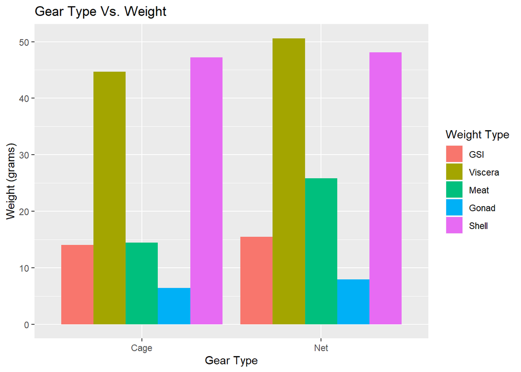

```r
gear_plot + labs(title = "Gear Type Vs. Weight", x= "Gear Type", y = "Weight (grams)", fill = "Weight Type")
```

#### 3. Differences in growth rate of Male and Female scallops

- These steps create a bar chart that compares the different types of weight measurements across gender:
- Summarise means of the different categories of weight, grouped by Sex.

```r
sex_GSI <- GSI_Data_Sheet_cleaned %>% group_by(Sex) %>% summarise(GSI = mean(GSI), Viscera = mean(Total.Viscera.Weight.), Meat = mean(Meat.Weight.), Gonad = mean(Gonad.Weight.), Shell = mean(Shell.Weight., na.rm = TRUE))
```

- Melt data into a format compatible with ggplot, grouped by “Sex”

```r
sex_GSI_long <- melt(sex_GSI, id = "Sex")
```

- Create plot of data, store in global variable

```r
sex_plot <- ggplot(sex_GSI_long, aes(Sex, value)) + geom_bar(aes(fill = variable), position = "dodge", stat = "identity")
```

- Add labels to graph

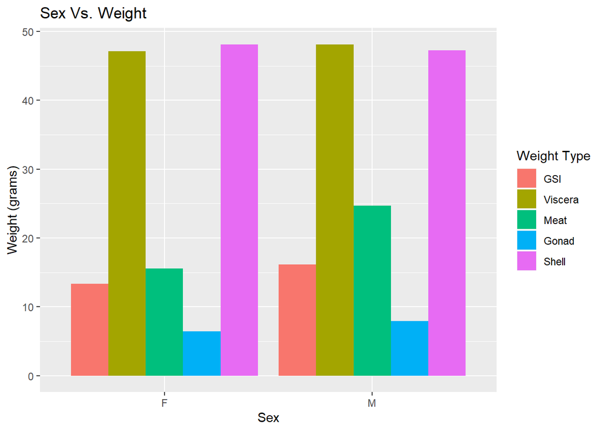

```r
sex_plot + labs(title = "Sex Vs. Weight", y = "Weight (grams)", fill = "Weight Type")
```

*This plot shows the relationship between the sexes of the scallops and their various categorization of weight. The goal of this chart is to see if there is any notable connection or difference between the genders regarding the weights and on the surface, and the biological differences between male and females could very well cause some differences in growth. However, there is not much of a notable difference here that we can see. Across the board, the weight measurements of the scallops seem relatively uniform across genders, with the exception of meat weight which was about 50% for males than for females.

#### 4. Temperature gradient over 2 years (2017 - 2019)

- These steps create a line graph that shows the temperature over 2017 till 2019.
- Read the csv file with column type

```r
cagetemp <- read_csv("Copy_of_Cage_5_2017_2019_cleaned.csv", col_types = cols(Date.Time = col_datetime(format = "%Y-%m-%d %H:%M:%S")))
```

- Average of the temperature by each day

```r
tempavg <- setNames(aggregate(cagetemp$`Temp...#20178444`, by=list(cagetemp$Date.Time), mean), c("Date", "Avg_temp"))
```

- Create plot of data

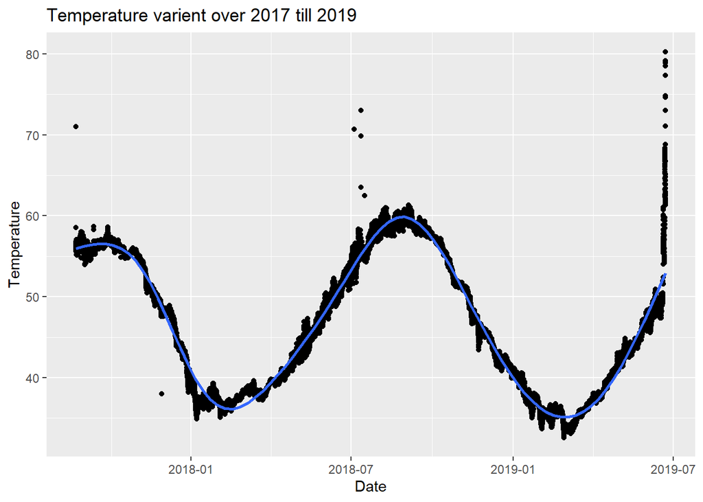

```r
ggplot(data = tempavg,mapping=aes(x=Date,y=Avg_temp)) + geom_point() + geom_smooth()+
  labs(x= "Date",y="Temperature")+
ggtitle("Temperature varient over 2017 till 2019")
```

#### 5. Temperature and Intensity difference in Net top and Net Bottom

- These steps create a line graph to show differences in temperature and intensity in Net top and Net bottom.
- Read the data from the csv file into the dataframe Copy_of_Net_5_Top_GSI_Top_cleaned.

```r
Copy_of_Net_5_Top_GSI_Top_cleaned <- read_csv("Copy_of_Net_5_Top_GSI_Top_cleaned.csv", col_types = cols(`Date.Time.GMT.-0400` = col_datetime(format = "%Y-%m-%d %H:%M:%S")))
```

- Generate the average temperature per day for Net Top

```r
Copy_of_Net_5_Top_GSI_Top_cleaned$`Date.Time.GMT.-0400` <- as.Date(Copy_of_Net_5_Top_GSI_Top_cleaned$`Date.Time.GMT.-0400`)
Net5TopAverage <- setNames(aggregate(Copy_of_Net_5_Top_GSI_Top_cleaned$`Temp.°F`, by=list(Copy_of_Net_5_Top_GSI_Top_cleaned$`Date.Time.GMT.-0400`), mean), c("Date", "Avg_temp_top"))
```

- Structure of dataframe Net5TopAverage

```r
str(Net5TopAverage)
```

```
## 'data.frame':    47 obs. of  2 variables:
##  $ Date        : Date, format: "2019-06-30" "2019-07-01" ...
##  $ Avg_temp_top: num  52.2 52.5 52.5 53.2 53.1 ...
```

- Summary of dataframe Net5TopAverage

```r
summary(Net5TopAverage)
```

```
##       Date             Avg_temp_top
##  Min.   :2019-06-30   Min.   :52.17
##  1st Qu.:2019-07-11   1st Qu.:54.19
##  Median :2019-07-23   Median :55.82
##  Mean   :2019-07-23   Mean   :55.33
##  3rd Qu.:2019-08-03   3rd Qu.:56.48
##  Max.   :2019-08-15   Max.   :57.53
```

- Read the data from the csv file into the dataframe Copy_of_Net_5_Bottom_GSI_2019_cleaned.

```r
Copy_of_Net_5_Bottom_GSI_2019_cleaned <- read_csv("Copy_of_Net_5_Bottom_GSI_2019_cleaned.csv", col_types = cols(`Date.Time.GMT.-0400` = col_datetime(format = "%Y-%m-%d %H:%M:%S")))
```

- Generate the average temperature per day for Net Bottom

```r
Copy_of_Net_5_Bottom_GSI_2019_cleaned$`Date.Time.GMT.-0400` <- as.Date(Copy_of_Net_5_Bottom_GSI_2019_cleaned$`Date.Time.GMT.-0400`)

Net5BottomAverage <- setNames(aggregate(Copy_of_Net_5_Bottom_GSI_2019_cleaned$`Temp.°F`, by=list(Copy_of_Net_5_Bottom_GSI_2019_cleaned$`Date.Time.GMT.-0400`), mean), c("Date", "Avg_Temp_bottom"))
```

- Structure of dataframe Net5BottomAverage

```r
str(Net5BottomAverage)
```

```
## 'data.frame':    47 obs. of  2 variables:
##  $ Date           : Date, format: "2019-06-30" "2019-07-01" ...
##  $ Avg_Temp_bottom: num  51.9 51.9 52 52.5 52.4 ...
```

- Summary of dataframe Net5BottomAverage

```r
summary(Net5BottomAverage)
```

```
##       Date            Avg_Temp_bottom
##  Min.   :2019-06-30   Min.   :51.87
##  1st Qu.:2019-07-11   1st Qu.:53.79
##  Median :2019-07-23   Median :55.34
##  Mean   :2019-07-23   Mean   :54.83
##  3rd Qu.:2019-08-03   3rd Qu.:56.09
##  Max.   :2019-08-15   Max.   :56.86
```

- Merge the dataframes.

```r
Net5TopVsBottom = setNames(merge(Net5TopAverage,Net5BottomAverage, by="Date"), c("Date", "Avg_temp_Top", "Avg_temp_bottom"))
```

- Structure of dataframe Net5TopVsBottom

```r
str(Net5TopVsBottom)
```

```
## 'data.frame':    47 obs. of  3 variables:
##  $ Date           : Date, format: "2019-06-30" "2019-07-01" ...
##  $ Avg_temp_Top   : num  52.2 52.5 52.5 53.2 53.1 ...
##  $ Avg_temp_bottom: num  51.9 51.9 52 52.5 52.4 ...
```

- Summary of dataframe Net5TopVsBottom

```r
summary(Net5TopVsBottom)
```

```
##       Date             Avg_temp_Top   Avg_temp_bottom
##  Min.   :2019-06-30   Min.   :52.17   Min.   :51.87
##  1st Qu.:2019-07-11   1st Qu.:54.19   1st Qu.:53.79
##  Median :2019-07-23   Median :55.82   Median :55.34
##  Mean   :2019-07-23   Mean   :55.33   Mean   :54.83
##  3rd Qu.:2019-08-03   3rd Qu.:56.48   3rd Qu.:56.09
##  Max.   :2019-08-15   Max.   :57.53   Max.   :56.86
```

- Melt data of the Temperature

```r
Net5TopVsBottom_long <- melt(Net5TopVsBottom, id = "Date")
```

- Create plot of data, store in global variable for temperature

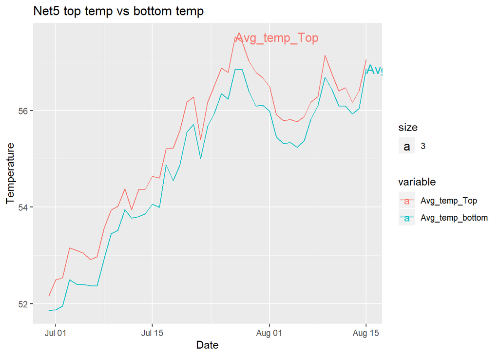

```r
ggplot(data = Net5TopVsBottom_long, mapping = aes(x= Date, y= value, color = variable))+
geom_line()+
geom_text(data = Net5TopVsBottom_long %>% group_by(variable) %>% filter(value== max(value)), aes(label= variable, x= Date,y= value,size = 3, hjust = 0))+
labs(x= "Date",y="Temperature")+
ggtitle("Net5 top temp vs bottom temp")
```

The graph is plotted to see the difference in the temperatures between top and bottom of Nets. Values are collected daily. The average of temperatures is calculated for each day and plotted against date for both Net top and Net bottom. From the graph it can be observed that the temperatures at top and bottom both follow the same trend and shows the difference is almost constant with few differences July first week and August second week.

- Generate the average intensity per day.

```r
Net5TopAverageInt <- setNames(aggregate(Copy_of_Net_5_Top_GSI_Top_cleaned$`Intensity..lum/ft²`, by=list(Copy_of_Net_5_Top_GSI_Top_cleaned$`Date.Time.GMT.-0400`), mean), c("Date", "Avg_int_top"))
```

- Structure of dataframe Net5TopAverage

```r
str(Net5TopAverageInt)
```

```
## 'data.frame':    47 obs. of  2 variables:
##  $ Date       : Date, format: "2019-06-30" "2019-07-01" ...
##  $ Avg_int_top: num  436 739 788 969 1010 ...
```

- Summary of dataframe Net5TopAverage

```r
summary(Net5TopAverageInt)
```

```
##       Date             Avg_int_top
##  Min.   :2019-06-30   Min.   : 202.4
##  1st Qu.:2019-07-11   1st Qu.: 435.6
##  Median :2019-07-23   Median : 581.0
##  Mean   :2019-07-23   Mean   : 605.8
##  3rd Qu.:2019-08-03   3rd Qu.: 775.5
##  Max.   :2019-08-15   Max.   :1018.4
```

- Generate the average Intensity per day at Bottom.

```r
Net5BottomAverageInt <- setNames(aggregate(Copy_of_Net_5_Bottom_GSI_2019_cleaned$`Intensity..lum/ft²`, by=list(Copy_of_Net_5_Bottom_GSI_2019_cleaned$`Date.Time.GMT.-0400`), mean), c("Date", "Avg_Temp_bottom"))
```

- Structure of dataframe Net5TopAverage

```r
str(Net5BottomAverageInt)
```

```
## 'data.frame':    47 obs. of  2 variables:
##  $ Date           : Date, format: "2019-06-30" "2019-07-01" ...
##  $ Avg_Temp_bottom: num  62.4 134.2 101.1 120.3 62.7 ...
```

- Summary of dataframe Net5TopAverage

```r
summary(Net5BottomAverageInt)
```

```
##       Date            Avg_Temp_bottom
##  Min.   :2019-06-30   Min.   :  2.221
##  1st Qu.:2019-07-11   1st Qu.: 14.449
##  Median :2019-07-23   Median : 27.982
##  Mean   :2019-07-23   Mean   : 35.094
##  3rd Qu.:2019-08-03   3rd Qu.: 43.203
##  Max.   :2019-08-15   Max.   :134.231
```

- Merge the dataframes.

```r
Net5TopVsBottomInt = setNames(merge(Net5TopAverageInt,Net5BottomAverageInt, by="Date"), c("Date", "Avg_Intensity_Top", "Avg_Intensity_bottom"))
```

- Structure of dataframe Net5TopVsBottom of Intensity

```r
str(Net5TopVsBottomInt)
```

```
## 'data.frame':    47 obs. of  3 variables:
##  $ Date                : Date, format: "2019-06-30" "2019-07-01" ...
##  $ Avg_Intensity_Top   : num  436 739 788 969 1010 ...
##  $ Avg_Intensity_bottom: num  62.4 134.2 101.1 120.3 62.7 ...
```

- Summary of dataframe Net5TopVsBottom of Intensity

```r
summary(Net5TopVsBottomInt)
```

```
##       Date            Avg_Intensity_Top Avg_Intensity_bottom
##  Min.   :2019-06-30   Min.   : 202.4    Min.   :  2.221
##  1st Qu.:2019-07-11   1st Qu.: 435.6    1st Qu.: 14.449
##  Median :2019-07-23   Median : 581.0    Median : 27.982
##  Mean   :2019-07-23   Mean   : 605.8    Mean   : 35.094
##  3rd Qu.:2019-08-03   3rd Qu.: 775.5    3rd Qu.: 43.203
##  Max.   :2019-08-15   Max.   :1018.4    Max.   :134.231
```

- Melt data of the Intensity

```r
Net5TopVsBottomInt_long <- melt(Net5TopVsBottomInt, id = "Date")
```

- Create plot of data, store in global variable for intensity

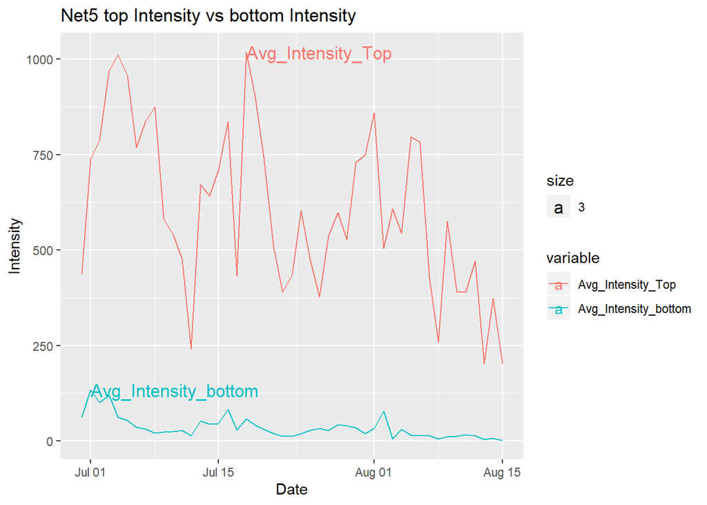

```r
ggplot(data = Net5TopVsBottomInt_long, mapping = aes(x= Date, y= value, color = variable))+
geom_line()+
geom_text(data = Net5TopVsBottomInt_long %>% group_by(variable) %>% filter(value== max(value)), aes(label= variable, x= Date,y= value,size = 3, hjust = 0))+
labs(x= "Date",y="Intensity")+
ggtitle("Net5 top Intensity vs bottom Intensity")
```

#### 6. Temperature difference between net surface temperature and cage bottom temperature.

- These steps create the line graph to compare the net surface and the cage bottom temperature.
- Generate the average temperature per day for dataframe Copy_of_Cage_6_2018_2019_cleaned.

```r
Copy_of_Cage_6_2018_2019_cleaned$Date.Time <- as.Date(Copy_of_Cage_6_2018_2019_cleaned$Date.Time)

Cage6Average <- setNames(aggregate(Copy_of_Cage_6_2018_2019_cleaned$`Temp...#20030572`, by=list(Copy_of_Cage_6_2018_2019_cleaned$Date.Time), mean), c("Date", "Avg_temp_Cage"))
```

- Exclusion of na of dataframe Cage6Average

```r
Cage6Average <- na.exclude(Cage6Average)
```

- Summary of dataframe Cage6Average

```r
summary(Cage6Average)
```

```
##       Date            Avg_temp_Cage
##  Min.   :2018-11-15   Min.   :33.15
##  1st Qu.:2019-01-08   1st Qu.:36.21
##  Median :2019-03-04   Median :40.17
##  Mean   :2019-03-04   Mean   :42.00
##  3rd Qu.:2019-04-27   3rd Qu.:44.48
##  Max.   :2019-06-21   Max.   :73.02
```

- Generate the average temperature per day for Copy_of_Net_2_2018_2019_cleaned.

```r
Copy_of_Net_2_2018_2019_cleaned$`Date.Time` <- as.Date(Copy_of_Net_2_2018_2019_cleaned$`Date.Time`)

Net2Average <- setNames(aggregate(Copy_of_Net_2_2018_2019_cleaned$`Temp...#10558683`, by=list(Copy_of_Net_2_2018_2019_cleaned$`Date.Time`), mean), c("Date", "Avg_Temp_Net"))
```

- Exclusion of na of dataframe Net2Average

```r
Net2Average <- na.exclude(Net2Average)
```

- Summary of dataframe Net2Average

```r
summary(Net2Average)
```

```
##       Date             Avg_Temp_Net
##  Min.   :2018-11-15   Min.   :33.25
##  1st Qu.:2019-01-08   1st Qu.:36.31
##  Median :2019-03-04   Median :40.22
##  Mean   :2019-03-04   Mean   :42.05
##  3rd Qu.:2019-04-27   3rd Qu.:44.41
##  Max.   :2019-06-21   Max.   :73.18
```

- Merge the dataframes Cage6Average and Net2Average

```r
Net2VsCage6 = merge(Cage6Average,Net2Average)
```

- Structure of dataframe Net2Average

```r
str(Net2VsCage6)
```

```
## 'data.frame':    219 obs. of  3 variables:
##  $ Date         : Date, format: "2018-11-15" "2018-11-16" ...
##  $ Avg_temp_Cage: num  47.2 47 47.1 47.1 47.3 ...
##  $ Avg_Temp_Net : num  47.3 47.2 47.1 47.1 47.4 ...
```

- Summary of dataframe Net2Average

```r
summary(Net2VsCage6)
```

```
##       Date            Avg_temp_Cage    Avg_Temp_Net
##  Min.   :2018-11-15   Min.   :33.15   Min.   :33.25
##  1st Qu.:2019-01-08   1st Qu.:36.21   1st Qu.:36.31
##  Median :2019-03-04   Median :40.17   Median :40.22
##  Mean   :2019-03-04   Mean   :42.00   Mean   :42.05
##  3rd Qu.:2019-04-27   3rd Qu.:44.48   3rd Qu.:44.41
##  Max.   :2019-06-21   Max.   :73.02   Max.   :73.18
```

- Melt data into a format compatible with ggplot

```r
Net2VsCage6_long <- melt(Net2VsCage6, id = "Date")
```

- Create plot of data, store in global variable

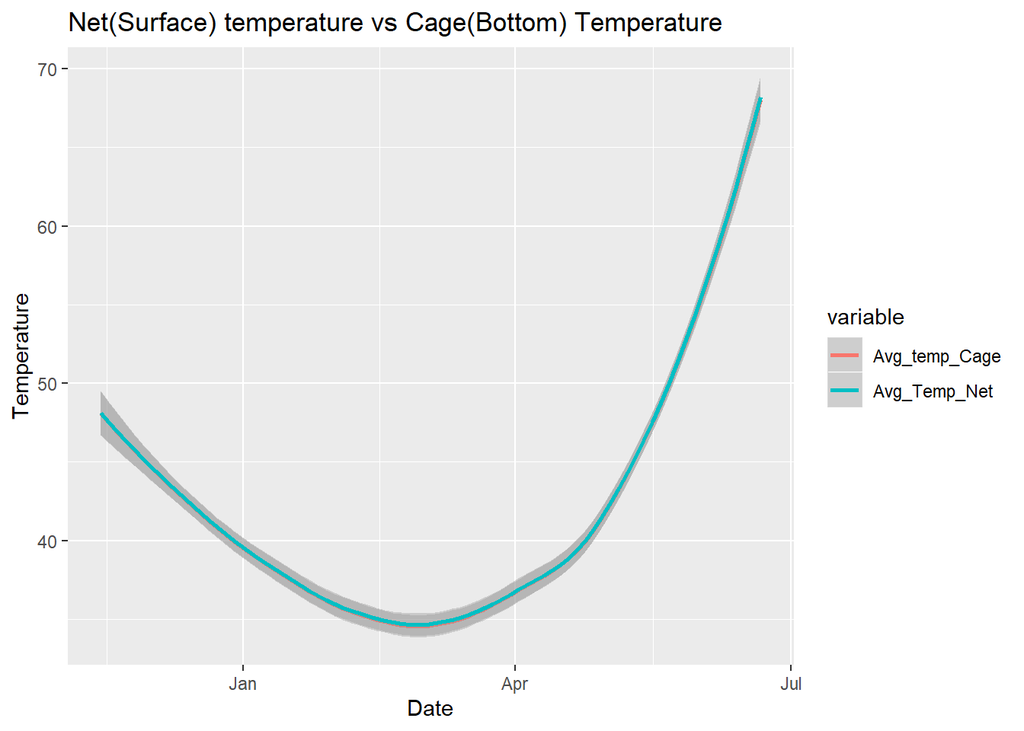

```r
ggplot(data = Net2VsCage6_long, mapping = aes(x= Date, y= value, color = variable))+ geom_smooth()+
labs(x= "Date",y="Temperature")+
ggtitle("Net(Surface) temperature vs Cage(Bottom) Temperature")
```

The graphs shows the trend of average temperature in Cage and Net. Both follow similar trend and are observed to be overlapping.

- Create facet plot of data, store in global variable

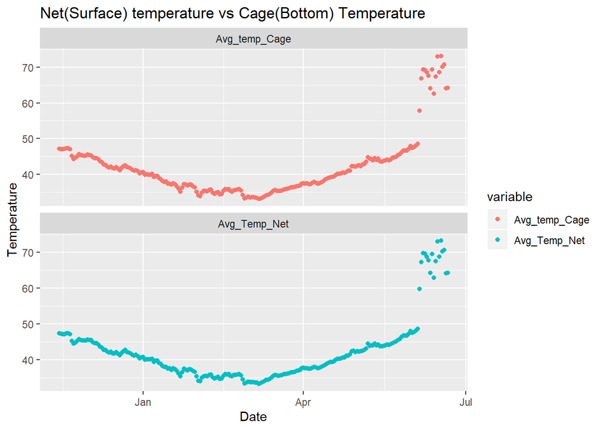

```r
ggplot(data = Net2VsCage6_long, mapping = aes(x= Date, y= value, color = variable))+ geom_point() + facet_wrap(~ variable, nrow=2)+
  labs(x= "Date",y="Temperature")+
  ggtitle("Net(Surface) temperature vs Cage(Bottom) Temperature")
```

#### 7. The effect of temperature on the Average GSI for scallops in cages.

- This will show the graph between the Average GSI and the Average temperature for the caged scallops.
  - Generate the average temperature per day for Copy_of_Cage_5_GSI_2019_cleaned.

```r
Copy_of_Cage_5_GSI_2019_cleaned$`Date.Time.GMT.-0400` <- as.Date(Copy_of_Cage_5_GSI_2019_cleaned$`Date.Time.GMT.-0400`)

Cage5Average <- setNames(aggregate(Copy_of_Cage_5_GSI_2019_cleaned$`Temp.°F`, by=list(Copy_of_Cage_5_GSI_2019_cleaned$`Date.Time.GMT.-0400`), mean), c("Date", "Avg_temp"))
```

- Structure of dataframe Cage5Average

```r
str(Cage5Average)
```

```
## 'data.frame':    26 obs. of  2 variables:
##  $ Date    : Date, format: "2019-06-30" "2019-07-01" ...
##  $ Avg_temp: num  51.4 51.3 51.5 52 52 ...
```

- Summary of dataframe Cage5Average

```r
summary(Cage5Average)
```

```
##       Date               Avg_temp
##  Min.   :2019-06-30   Min.   :51.33
##  1st Qu.:2019-07-06   1st Qu.:52.01
##  Median :2019-07-12   Median :53.46
##  Mean   :2019-07-12   Mean   :53.39
##  3rd Qu.:2019-07-18   3rd Qu.:54.48
##  Max.   :2019-07-25   Max.   :55.74
```

- Fetch only the Cage Gear Type from the GSI_Data_Sheet.

```r
GSI_Data_sheet_cage <- subset(GSI_Data_Sheet_cleaned, Gear.Type == "Cage")
```

- Merge the temperature dataframe with the GSI dataframe.

```r
GSI_Temp_Cage <- merge(GSI_Data_sheet_cage, Cage5Average, by.x="Date", by.y = "Date", sort = TRUE)
```

- Summarise mean of temperature and GSI, grouped by Date.

```r
temp_GSI <- GSI_Temp_Cage %>% group_by(Date) %>% summarise(GSI = mean(GSI), Temp = mean(Avg_temp), Gear.Type = "Cage", na.rm = TRUE)
```

- Plot temperature with GSI

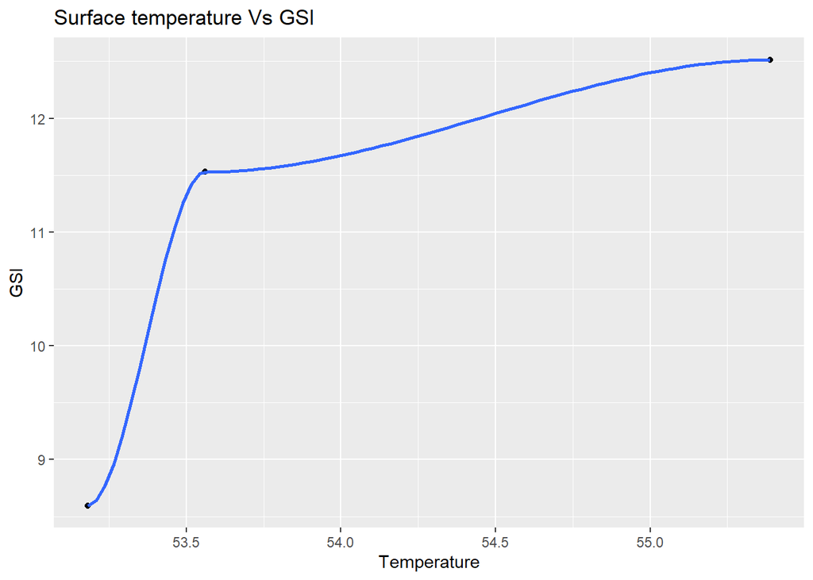

```r
ggplot(data = temp_GSI, mapping = aes(x=Temp, y=GSI)) + geom_point() + geom_smooth()+
labs(x= "Temperature",y="GSI")+
  ggtitle("Surface temperature Vs GSI")
```

This graphs is plotted for GSI aganist temperature. It can be observed that the GSI increases with the increase in temperature. A steep increase can be observed till the temperature around 53.5 but with temperatures beyond 53.5, GSI only increased gradually but not radically.

### CONTRIBUTION STATEMENT

- The work for this assignment was distributed as follows:
  - Connor McCoy
    1. Created graph for Cage Vs Weight Comparison
    2. Created graph for Sex Vs Weight Comparison
    3. Created RMarkdown document.
  - Julie Sunny Mathew
    1. Temperature difference between net surface temperature and cage bottom temperature.
    2. The effect of temperature on the Average GSI for scallops in cages.
  - Swetha Byluppala
    1. What is temperature gradient over two years?
    2. What is the temperature difference between surface temperature and cage bottom temperature?
- As the role of the Proof Reader is alternating for every assignment, Connor McCoy fulfilled the role of Proof Reader for the RPlots Documentation.